# Unsupervised Learning: Trade & Ahead

## Problem Statement

### Context

The stock market has consistently proven to be a good place to invest in and save for the future. There are a lot of compelling reasons to invest in stocks. It can help in fighting inflation, create wealth, and also provides some tax benefits. Good steady returns on investments over a long period of time can also grow a lot more than seems possible. Also, thanks to the power of compound interest, the earlier one starts investing, the larger the corpus one can have for retirement. Overall, investing in stocks can help meet life's financial aspirations.

It is important to maintain a diversified portfolio when investing in stocks in order to maximise earnings under any market condition. Having a diversified portfolio tends to yield higher returns and face lower risk by tempering potential losses when the market is down. It is often easy to get lost in a sea of financial metrics to analyze while determining the worth of a stock, and doing the same for a multitude of stocks to identify the right picks for an individual can be a tedious task. By doing a cluster analysis, one can identify stocks that exhibit similar characteristics and ones which exhibit minimum correlation. This will help investors better analyze stocks across different market segments and help protect against risks that could make the portfolio vulnerable to losses.

### Objective

Trade&Ahead is a financial consultancy firm who provide their customers with personalized investment strategies. They have hired you as a Data Scientist and provided you with data comprising stock price and some financial indicators for a few companies listed under the New York Stock Exchange. They have assigned you the tasks of analyzing the data, grouping the stocks based on the attributes provided, and sharing insights about the characteristics of each group.

### Data Dictionary

- Ticker Symbol: An abbreviation used to uniquely identify publicly traded shares of a particular stock on a particular stock market
- Company: Name of the company
- GICS Sector: The specific economic sector assigned to a company by the Global Industry Classification Standard (GICS) that best defines its business operations
- GICS Sub Industry: The specific sub-industry group assigned to a company by the Global Industry Classification Standard (GICS) that best defines its business operations
- Current Price: Current stock price in dollars
- Price Change: Percentage change in the stock price in 13 weeks
- Volatility: Standard deviation of the stock price over the past 13 weeks
- ROE: A measure of financial performance calculated by dividing net income by shareholders' equity (shareholders' equity is equal to a company's assets minus its debt)
- Cash Ratio: The ratio of a company's total reserves of cash and cash equivalents to its total current liabilities
- Net Cash Flow: The difference between a company's cash inflows and outflows (in dollars)
- Net Income: Revenues minus expenses, interest, and taxes (in dollars)
- Earnings Per Share: Company's net profit divided by the number of common shares it has outstanding (in dollars)
- Estimated Shares Outstanding: Company's stock currently held by all its shareholders
- P/E Ratio: Ratio of the company's current stock price to the earnings per share
- P/B Ratio: Ratio of the company's stock price per share by its book value per share (book value of a company is the net difference between that company's total assets and total liabilities)

## Importing necessary libraries and data

```python
import time
import pandas as pd
import matplotlib.pyplot as plt
import numpy as np
import seaborn as sns

%load_ext nb_black

# Ignores Warnings
import warnings

warnings.filterwarnings("ignore")


from sklearn.cluster import AgglomerativeClustering
from scipy.stats import zscore

# Hierarchal Clustering Libraries
from scipy.cluster.hierarchy import cophenet, dendrogram, linkage
from scipy.spatial.distance import pdist  # Pairwise distribution between data points
```

```python
# Reading the data
df = pd.read_csv("stock_data.csv")
df.head()
```

|  | Ticker Symbol | Security | GICS Sector | GICS Sub Industry | Current Price | Price Change | Volatility | ROE | Cash Ratio | Net Cash Flow | Net Income | Earnings Per Share | Estimated Shares Outstanding | P/E Ratio | P/B Ratio |
| --- | --- | --- | --- | --- | --- | --- | --- | --- | --- | --- | --- | --- | --- | --- | --- |
| 0 | AAL | American Airlines Group | Industrials | Airlines | 42.349998 | 9.999995 | 1.687151 | 135 | 51 | -604000000 | 7610000000 | 11.39 | 6.681299e+08 | 3.718174 | -8.784219 |
| 1 | ABBV | AbbVie | Health Care | Pharmaceuticals | 59.240002 | 8.339433 | 2.197887 | 130 | 77 | 51000000 | 5144000000 | 3.15 | 1.633016e+09 | 18.806350 | -8.750068 |
| 2 | ABT | Abbott Laboratories | Health Care | Health Care Equipment | 44.910000 | 11.301121 | 1.273646 | 21 | 67 | 938000000 | 4423000000 | 2.94 | 1.504422e+09 | 15.275510 | -0.394171 |
| 3 | ADBE | Adobe Systems Inc | Information Technology | Application Software | 93.940002 | 13.977195 | 1.357679 | 9 | 180 | -240840000 | 629551000 | 1.26 | 4.996437e+08 | 74.555557 | 4.199651 |
| 4 | ADI | Analog Devices, Inc. | Information Technology | Semiconductors | 55.320000 | -1.827858 | 1.701169 | 14 | 272 | 315120000 | 696878000 | 0.31 | 2.247994e+09 | 178.451613 | 1.059810 |

## Data Overview and Preprocessing

- Observations
- Sanity checks
- Duplicate value check
- Missing value treatment
- Outlier check

```python
# Print Rows and Columns of Dataframe
df.shape
```

```
(340, 15)
```

```python
# Checking for Duplicates
print(df.duplicated().sum())

# Checking for null values
df.isnull().sum()
```

```
0
```

```
Ticker Symbol                   0
Security                        0
GICS Sector                     0
GICS Sub Industry               0
Current Price                   0
Price Change                    0
Volatility                      0
ROE                             0
Cash Ratio                      0
Net Cash Flow                   0
Net Income                      0
Earnings Per Share              0
Estimated Shares Outstanding    0
P/E Ratio                       0
P/B Ratio                       0
dtype: int64
```

```python
# Checking Datatypes
df.info()
```

```
<class 'pandas.core.frame.DataFrame'>
RangeIndex: 340 entries, 0 to 339
Data columns (total 15 columns):
 #   Column                        Non-Null Count  Dtype
---  ------                        --------------  -----
 0   Ticker Symbol                 340 non-null    object
 1   Security                      340 non-null    object
 2   GICS Sector                   340 non-null    object
 3   GICS Sub Industry             340 non-null    object
 4   Current Price                 340 non-null    float64
 5   Price Change                  340 non-null    float64
 6   Volatility                    340 non-null    float64
 7   ROE                           340 non-null    int64
 8   Cash Ratio                    340 non-null    int64
 9   Net Cash Flow                 340 non-null    int64
 10  Net Income                    340 non-null    int64
 11  Earnings Per Share            340 non-null    float64
 12  Estimated Shares Outstanding  340 non-null    float64
 13  P/E Ratio                     340 non-null    float64
 14  P/B Ratio                     340 non-null    float64
dtypes: float64(7), int64(4), object(4)
memory usage: 40.0+ KB
```

```python
# Printing statitical summary of the data
df.describe()
```

|  | Current Price | Price Change | Volatility | ROE | Cash Ratio | Net Cash Flow | Net Income | Earnings Per Share | Estimated Shares Outstanding | P/E Ratio | P/B Ratio |
| --- | --- | --- | --- | --- | --- | --- | --- | --- | --- | --- | --- |
| count | 340.000000 | 340.000000 | 340.000000 | 340.000000 | 340.000000 | 3.400000e+02 | 3.400000e+02 | 340.000000 | 3.400000e+02 | 340.000000 | 340.000000 |
| mean | 80.862345 | 4.078194 | 1.525976 | 39.597059 | 70.023529 | 5.553762e+07 | 1.494385e+09 | 2.776662 | 5.770283e+08 | 32.612563 | -1.718249 |
| std | 98.055086 | 12.006338 | 0.591798 | 96.547538 | 90.421331 | 1.946365e+09 | 3.940150e+09 | 6.587779 | 8.458496e+08 | 44.348731 | 13.966912 |
| min | 4.500000 | -47.129693 | 0.733163 | 1.000000 | 0.000000 | -1.120800e+10 | -2.352800e+10 | -61.200000 | 2.767216e+07 | 2.935451 | -76.119077 |
| 25% | 38.555000 | -0.939484 | 1.134878 | 9.750000 | 18.000000 | -1.939065e+08 | 3.523012e+08 | 1.557500 | 1.588482e+08 | 15.044653 | -4.352056 |
| 50% | 59.705000 | 4.819505 | 1.385593 | 15.000000 | 47.000000 | 2.098000e+06 | 7.073360e+08 | 2.895000 | 3.096751e+08 | 20.819876 | -1.067170 |
| 75% | 92.880001 | 10.695493 | 1.695549 | 27.000000 | 99.000000 | 1.698108e+08 | 1.899000e+09 | 4.620000 | 5.731175e+08 | 31.764755 | 3.917066 |
| max | 1274.949951 | 55.051683 | 4.580042 | 917.000000 | 958.000000 | 2.076400e+10 | 2.444200e+10 | 50.090000 | 6.159292e+09 | 528.039074 | 129.064585 |

- Current Stock Price seems to have heavy outliers as max value is more than 10 times higher than the 75th percentile

```python
# Checking no. of entries where current price is greater than 600 USD
print(df[df["Current Price"] > 600].shape[0])
```

```
2
```

- While our dataset is very limited, removing these 2 rows will allow us to better analyse the rest of the data

```python
# Removing the 2 outliers and checking the shape
df = df[df["Current Price"] < 600]
df.shape
```

```
(338, 15)
```

#### Feature Magnitude Adjustment:

- As some columns tackle net company wide metrics they have generally high values, we will adjust them to improve visual simplicity at the moment however further feature scaling will need to be done when dealing with specific clutering techniques

```python
# Dividing high magnitude columns by 10^7 and adjusting column name accordingly
df[
    [
        "Net Cash Flow (x10^7)",
        "Net Income (x10^7)",
        "Estimated Shares Outstanding (x10^7)",
    ]
] = (
    df[["Net Cash Flow", "Net Income", "Estimated Shares Outstanding"]] / 10000000
)

df.drop(
    ["Net Cash Flow", "Net Income", "Estimated Shares Outstanding"],
    axis=1,
    inplace=True,
)
df
```

|  | Ticker Symbol | Security | GICS Sector | GICS Sub Industry | Current Price | Price Change | Volatility | ROE | Cash Ratio | Earnings Per Share | P/E Ratio | P/B Ratio | Net Cash Flow (x10^7) | Net Income (x10^7) | Estimated Shares Outstanding (x10^7) |
| --- | --- | --- | --- | --- | --- | --- | --- | --- | --- | --- | --- | --- | --- | --- | --- |
| 0 | AAL | American Airlines Group | Industrials | Airlines | 42.349998 | 9.999995 | 1.687151 | 135 | 51 | 11.39 | 3.718174 | -8.784219 | -60.4000 | 761.0000 | 66.812994 |
| 1 | ABBV | AbbVie | Health Care | Pharmaceuticals | 59.240002 | 8.339433 | 2.197887 | 130 | 77 | 3.15 | 18.806350 | -8.750068 | 5.1000 | 514.4000 | 163.301587 |
| 2 | ABT | Abbott Laboratories | Health Care | Health Care Equipment | 44.910000 | 11.301121 | 1.273646 | 21 | 67 | 2.94 | 15.275510 | -0.394171 | 93.8000 | 442.3000 | 150.442177 |
| 3 | ADBE | Adobe Systems Inc | Information Technology | Application Software | 93.940002 | 13.977195 | 1.357679 | 9 | 180 | 1.26 | 74.555557 | 4.199651 | -24.0840 | 62.9551 | 49.964365 |
| 4 | ADI | Analog Devices, Inc. | Information Technology | Semiconductors | 55.320000 | -1.827858 | 1.701169 | 14 | 272 | 0.31 | 178.451613 | 1.059810 | 31.5120 | 69.6878 | 224.799355 |
| ... | ... | ... | ... | ... | ... | ... | ... | ... | ... | ... | ... | ... | ... | ... | ... |
| 335 | YHOO | Yahoo Inc. | Information Technology | Internet Software & Services | 33.259998 | 14.887727 | 1.845149 | 15 | 459 | -4.64 | 28.976191 | 6.261775 | -103.2187 | -435.9082 | 93.945733 |
| 336 | YUM | Yum! Brands Inc | Consumer Discretionary | Restaurants | 52.516175 | -8.698917 | 1.478877 | 142 | 27 | 2.97 | 17.682214 | -3.838260 | 15.9000 | 129.3000 | 43.535354 |
| 337 | ZBH | Zimmer Biomet Holdings | Health Care | Health Care Equipment | 102.589996 | 9.347683 | 1.404206 | 1 | 100 | 0.78 | 131.525636 | -23.884449 | 37.6000 | 14.7000 | 18.846154 |
| 338 | ZION | Zions Bancorp | Financials | Regional Banks | 27.299999 | -1.158588 | 1.468176 | 4 | 99 | 1.20 | 22.749999 | -0.063096 | -4.3623 | 30.9471 | 25.789250 |
| 339 | ZTS | Zoetis | Health Care | Pharmaceuticals | 47.919998 | 16.678836 | 1.610285 | 32 | 65 | 0.68 | 70.470585 | 1.723068 | 27.2000 | 33.9000 | 49.852941 |

338 rows × 15 columns

## Exploratory Data Analysis (EDA)

- EDA is an important part of any project involving data.
- It is important to investigate and understand the data better before building a model with it.
- A few questions have been mentioned below which will help you approach the analysis in the right manner and generate insights from the data.
- A thorough analysis of the data, in addition to the questions mentioned below, should be done.

**Questions**:

1. What does the distribution of stock prices look like?
2. The stocks of which economic sector have seen the maximum price increase on average?
3. How are the different variables correlated with each other?
4. Cash ratio provides a measure of a company's ability to cover its short-term obligations using only cash and cash equivalents. How does the average cash ratio vary across economic sectors?
5. P/E ratios can help determine the relative value of a company's shares as they signify the amount of money an investor is willing to invest in a single share of a company per dollar of its earnings. How does the P/E ratio vary, on average, across economic sectors?

### [1] Distribution of Stock Prices

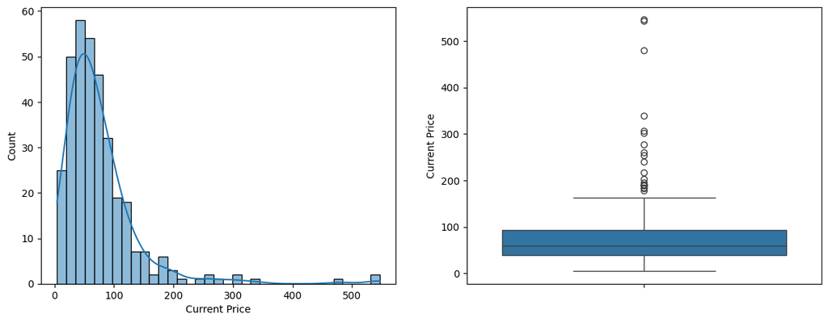

```python
# Creating a histogram and boxplot to visualize distribution of Current Stock Prices
f, axes = plt.subplots(1, 2, figsize=(14, 5))

sns.histplot(df["Current Price"], ax=axes[0], kde=True)
sns.boxplot(y="Current Price", data=df, ax=axes[1])

plt.show()
```

- Majority of stock prices lie between 0-100 USD with the median stock price at approximately 60 USD

### [2] Which economic sector had the bigest stock boom

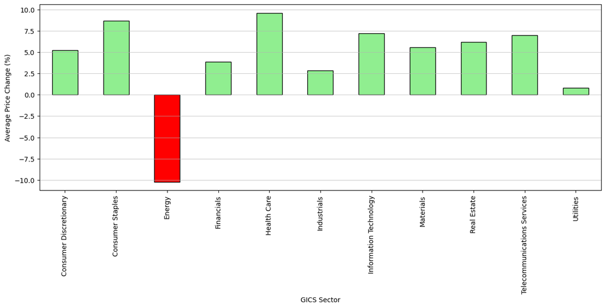

```python
# Creating a Barplot of Average Price Change grouped by GICS Sector
AvgPriceChange = df.groupby("GICS Sector")["Price Change"].mean(numeric_only=True)
colors = np.where(AvgPriceChange >= 0, "lightgreen", "r")

plt.figure(figsize=(15, 5))
AvgPriceChange.plot.bar(color=colors, edgecolor="black")
plt.grid(axis="y", linewidth=0.5)
plt.ylabel("Average Price Change (%)")
```

- Healthcare has the highest average stock price gain in the past 13 weeks closely followed by Consumer Staples
- While most sectors see noticable increases in average stock price, the Utilities Sector roughly breaks even while the Energy sector sees a massive dip of over 10% in average stock price

### [3] Checking correlation of numerical variables

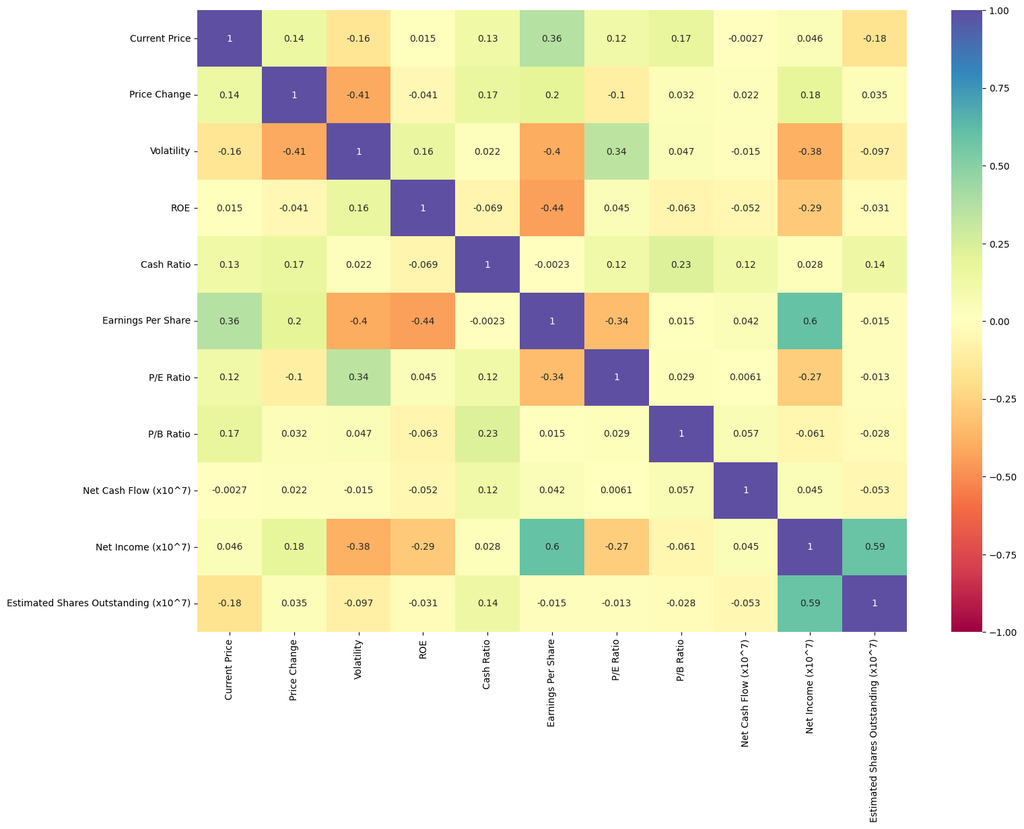

```python
# Creating a Correlation Matrix Heatmap of the numerical variables
plt.figure(figsize=(17, 12))
sns.heatmap(df.corr(numeric_only=True), annot=True, cmap="Spectral", vmin=-1, vmax=1)
plt.show()
```

- Volatility is negatively correlated with Price Change, Earnings per Share and Net Income which makes sense as more rapid stock price changes are likely to alienate investors and lead them to sell their shares at a lower price
- Net income and the Earnings per share as well as the Estimated Shares Outstanding are highly positively correlated

### [4] Average Cash Ratio grouped by GICS Sector

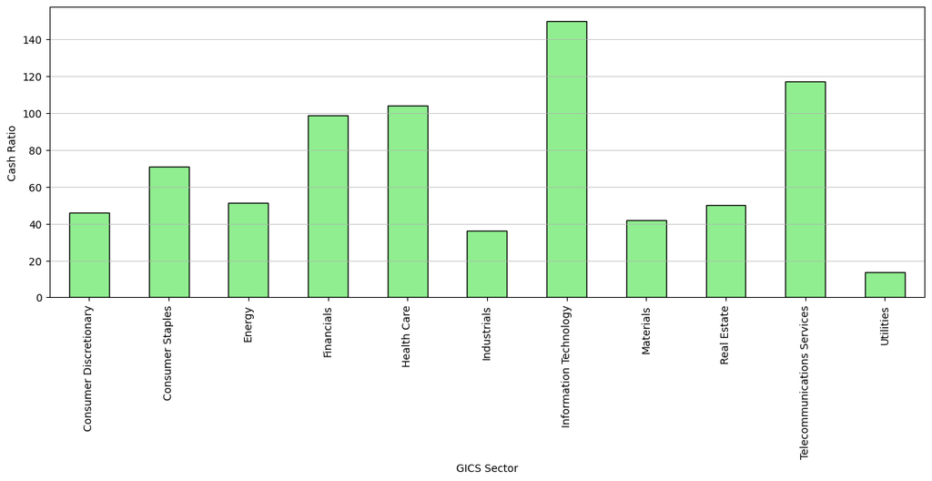

```python
# Creating a Barplot of Average Cash Ratio grouped by GICS Sector
plt.figure(figsize=(15, 5))
df.groupby("GICS Sector")["Cash Ratio"].mean(numeric_only=True).plot.bar(
    color="lightgreen", edgecolor="black"
)
plt.grid(axis="y", linewidth=0.5)
plt.ylabel("Cash Ratio")
```

- The 4 sectors with the highest average cash ratio in order are: IT, Telecommunication, Health Care and Financials
- Utilities has the lowest average cash ratio indicating the sector's limited ability in covering liabilities with liquid assets

### [5] Average P/E Ratio grouped by GICS Sector

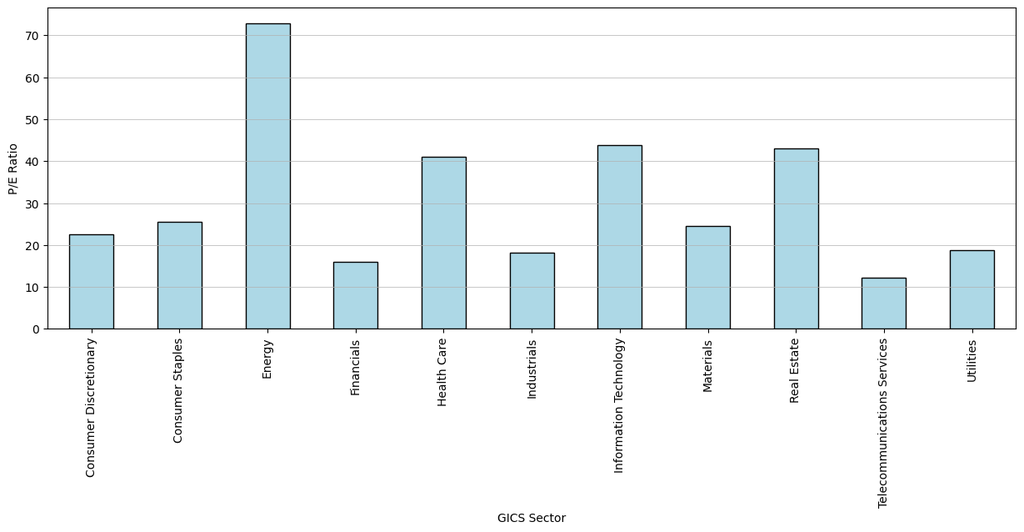

```python
# Creating a Barplot of Average P/E Ratio grouped by GICS Sector
plt.figure(figsize=(15, 5))
df.groupby("GICS Sector")["P/E Ratio"].mean(numeric_only=True).plot.bar(
    color="lightblue", edgecolor="black"
)
plt.grid(axis="y", linewidth=0.5)
plt.ylabel("P/E Ratio")
```

- The P/E Ratio for the Energy Sector is significantly higher than others
- This could be a combination of energy sector earnings decreasing and the stock prices slowly catching up to match the earnings, explaining the rapid decrease in share prices and increased volatility of the enrgy sector as a whole
- The rest of the sectors' P/E ratio are much lower with Financials, Industrials, Telecomms and Utilities all having a P/E Ratio of less than 20

### Filtering and Scaling the dataset

```python
# Creating an Attribute dataframe containing only numerical columns
dfAttr = df.iloc[:, 4:]
dfAttr.head(3)
```

|  | Current Price | Price Change | Volatility | ROE | Cash Ratio | Earnings Per Share | P/E Ratio | P/B Ratio | Net Cash Flow (x10^7) | Net Income (x10^7) | Estimated Shares Outstanding (x10^7) |
| --- | --- | --- | --- | --- | --- | --- | --- | --- | --- | --- | --- |
| 0 | 42.349998 | 9.999995 | 1.687151 | 135 | 51 | 11.39 | 3.718174 | -8.784219 | -60.4 | 761.0 | 66.812994 |
| 1 | 59.240002 | 8.339433 | 2.197887 | 130 | 77 | 3.15 | 18.806350 | -8.750068 | 5.1 | 514.4 | 163.301587 |
| 2 | 44.910000 | 11.301121 | 1.273646 | 21 | 67 | 2.94 | 15.275510 | -0.394171 | 93.8 | 442.3 | 150.442177 |

```python
# Scaling the dataset using Z-scores
dfScaled = dfAttr.apply(zscore)
dfScaled.head(3)
```

|  | Current Price | Price Change | Volatility | ROE | Cash Ratio | Earnings Per Share | P/E Ratio | P/B Ratio | Net Cash Flow (x10^7) | Net Income (x10^7) | Estimated Shares Outstanding (x10^7) |
| --- | --- | --- | --- | --- | --- | --- | --- | --- | --- | --- | --- |
| 0 | -0.503711 | 0.503338 | 0.270413 | 0.985489 | -0.207239 | 1.440661 | -0.778201 | -0.503954 | -0.339649 | 1.550239 | 0.105382 |
| 1 | -0.247603 | 0.364094 | 1.132421 | 0.933766 | 0.080564 | 0.083798 | -0.350452 | -0.501511 | -0.003016 | 0.925184 | 1.245111 |
| 2 | -0.464893 | 0.612442 | -0.427491 | -0.193792 | -0.030130 | 0.049218 | -0.450551 | 0.096015 | 0.452853 | 0.742433 | 1.093214 |

## K-means Clustering

```python
# Importing KMeans libraries
from sklearn.cluster import KMeans
from scipy.spatial.distance import cdist
```

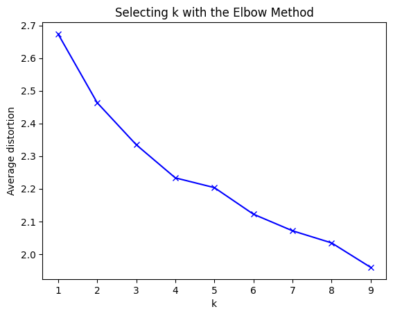

```python
# Finding optimal no. of clusters
clusters = range(1, 10)
meanDistortions = []

for k in clusters:
    KMmodel = KMeans(n_clusters=k, n_init=10)
    KMmodel.fit(dfScaled)
    prediction = KMmodel.predict(dfScaled)
    meanDistortions.append(
        sum(np.min(cdist(dfScaled, KMmodel.cluster_centers_, "euclidean"), axis=1))
        / dfScaled.shape[0]
    )


plt.plot(clusters, meanDistortions, "bx-")
plt.xlabel("k")
plt.ylabel("Average distortion")
plt.title("Selecting k with the Elbow Method")
```

- There is a strong change in gradient at k=4, we will try using 4 nodes

```python
start_time = time.time()

# Using K = 4
KMmodel = KMeans(4)
KMmodel.fit(dfScaled)
prediction = KMmodel.predict(dfScaled)

# Checking Output time
t1 = time.time() - start_time
print("--- %s seconds ---" % (time.time() - start_time))

# Adding the Cluster designation for each datapoint
df["GROUP"] = prediction
dfScaled["GROUP"] = prediction
print("Groups Assigned : \n")
df.head()
```

```
--- 0.02901768684387207 seconds ---
Groups Assigned :
```

|  | Ticker Symbol | Security | GICS Sector | GICS Sub Industry | Current Price | Price Change | Volatility | ROE | Cash Ratio | Earnings Per Share | P/E Ratio | P/B Ratio | Net Cash Flow (x10^7) | Net Income (x10^7) | Estimated Shares Outstanding (x10^7) | GROUP |
| --- | --- | --- | --- | --- | --- | --- | --- | --- | --- | --- | --- | --- | --- | --- | --- | --- |
| 0 | AAL | American Airlines Group | Industrials | Airlines | 42.349998 | 9.999995 | 1.687151 | 135 | 51 | 11.39 | 3.718174 | -8.784219 | -60.400 | 761.0000 | 66.812994 | 0 |
| 1 | ABBV | AbbVie | Health Care | Pharmaceuticals | 59.240002 | 8.339433 | 2.197887 | 130 | 77 | 3.15 | 18.806350 | -8.750068 | 5.100 | 514.4000 | 163.301587 | 0 |
| 2 | ABT | Abbott Laboratories | Health Care | Health Care Equipment | 44.910000 | 11.301121 | 1.273646 | 21 | 67 | 2.94 | 15.275510 | -0.394171 | 93.800 | 442.3000 | 150.442177 | 0 |
| 3 | ADBE | Adobe Systems Inc | Information Technology | Application Software | 93.940002 | 13.977195 | 1.357679 | 9 | 180 | 1.26 | 74.555557 | 4.199651 | -24.084 | 62.9551 | 49.964365 | 0 |
| 4 | ADI | Analog Devices, Inc. | Information Technology | Semiconductors | 55.320000 | -1.827858 | 1.701169 | 14 | 272 | 0.31 | 178.451613 | 1.059810 | 31.512 | 69.6878 | 224.799355 | 2 |

```python
# Display number of datapoints assigned to each cluster
o1 = df["GROUP"].value_counts()
o1
```

```
0    282
2     29
1     18
3      9
Name: GROUP, dtype: int64
```

```python
# Looking at the average metrics for each cluster
df.groupby(["GROUP"]).mean()
```

| GROUP | Current Price | Price Change | Volatility | ROE | Cash Ratio | Earnings Per Share | P/E Ratio | P/B Ratio | Net Cash Flow (x10^7) | Net Income (x10^7) | Estimated Shares Outstanding (x10^7) |
| --- | --- | --- | --- | --- | --- | --- | --- | --- | --- | --- | --- |
| 0 | 72.610298 | 5.494707 | 1.408011 | 35.014184 | 55.900709 | 3.592358 | 23.824891 | -3.109077 | -1.452036 | 145.949267 | 43.192166 |
| 1 | 187.097962 | 7.937509 | 1.552535 | 23.944444 | 303.555556 | 5.823889 | 38.905247 | 18.368822 | 303.031244 | 355.426539 | 93.791950 |
| 2 | 44.084138 | -13.370841 | 2.806348 | 100.000000 | 62.517241 | -8.831034 | 102.603487 | 0.560411 | -13.323121 | -359.470017 | 54.841299 |
| 3 | 46.672222 | 5.166566 | 1.079367 | 25.000000 | 58.333333 | 3.435556 | 15.596051 | -6.354193 | -304.066667 | 1484.844444 | 456.495995 |

```
array([[<Axes: title={'center': 'Cash Ratio'}, xlabel='[GROUP]'>,
        <Axes: title={'center': 'Current Price'}, xlabel='[GROUP]'>,
        <Axes: title={'center': 'Earnings Per Share'}, xlabel='[GROUP]'>,
        <Axes: title={'center': 'Estimated Shares Outstanding (x10^7)'}, xlabel='[GROUP]'>,
        <Axes: title={'center': 'Net Cash Flow (x10^7)'}, xlabel='[GROUP]'>,
        <Axes: title={'center': 'Net Income (x10^7)'}, xlabel='[GROUP]'>],
       [<Axes: title={'center': 'P/B Ratio'}, xlabel='[GROUP]'>,
        <Axes: title={'center': 'P/E Ratio'}, xlabel='[GROUP]'>,
        <Axes: title={'center': 'Price Change'}, xlabel='[GROUP]'>,
        <Axes: title={'center': 'ROE'}, xlabel='[GROUP]'>,
        <Axes: title={'center': 'Volatility'}, xlabel='[GROUP]'>,
        <Axes: >]], dtype=object)
```

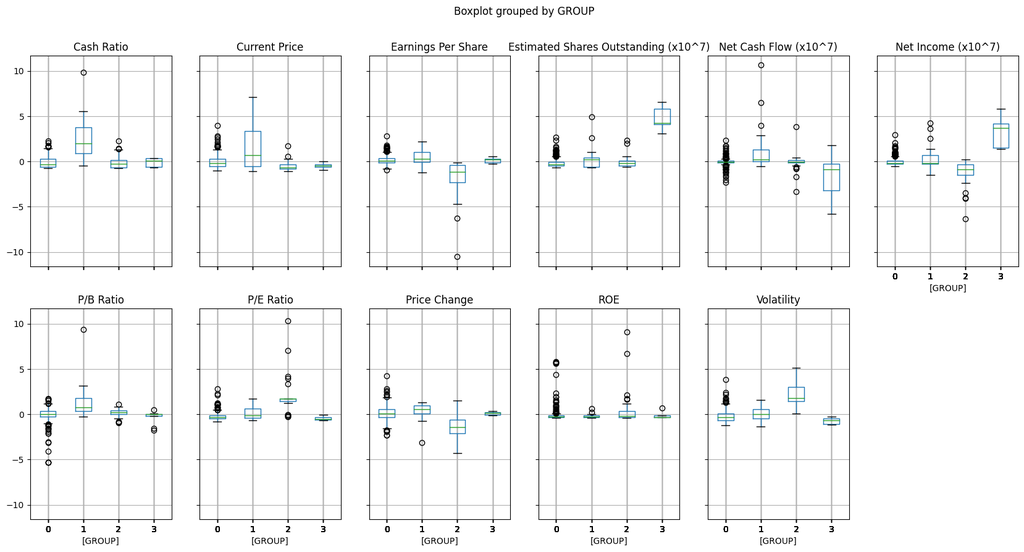

```python
# Creating multiple boxplots to visualize and distinguish cluster features
dfScaled.boxplot(by="GROUP", layout=(2, 6), figsize=(20, 10))
```

### Section Summary:

#### From the metric grouping and box plot we can infer:

- Cluster 2 is the most volatile cluster with high P/E Ratios, losses in share prices and net income
- Cluster 0 consists of the majority data and lies around the median of each metric of the box plot with some strong outliers
- Cluster 1 is characterized by it's high P/B and Cash Ratios as well as high current share prices
- Cluster 3 has the highest net income of all clusters by a wide margin with high outstanding estimated shares and a largely negative net cash flow

## Hierarchical Clustering

### [1] Creating a Clustering Algotrithm using Average linkage and 3 clusters

```python
start_time = time.time()

# Creating and fitting the hierarchal clustering model w/ no. of clusters = 3 and Eucledian distance measurement
model = AgglomerativeClustering(n_clusters=3, affinity="euclidean", linkage="average")
model.fit(dfScaled)

# Checking Output time
t2 = time.time() - start_time
print("--- %s seconds ---" % (time.time() - start_time))
```

```
--- 0.00398707389831543 seconds ---
```

```python
# Creating a new column labelling which cluster the datapoint belongs & checking the total number of datapoints for each cluster
dfAttr["labels"] = model.labels_
o2 = dfAttr["labels"].value_counts()
o2
```

```
0    335
1      2
2      1
Name: labels, dtype: int64
```

- An overwhelming majority of data belong to cluster 0
- We can try tweaking the linkage, clusters and distance measurements to see if it will distribute the datapoints better

```python
# Checking the average statistics of each cluster
dfAttr.groupby(["labels"]).mean()
```

| labels | Current Price | Price Change | Volatility | ROE | Cash Ratio | Earnings Per Share | P/E Ratio | P/B Ratio | Net Cash Flow (x10^7) | Net Income (x10^7) | Estimated Shares Outstanding (x10^7) |
| --- | --- | --- | --- | --- | --- | --- | --- | --- | --- | --- | --- |
| 0 | 75.787246 | 4.064498 | 1.515873 | 35.277612 | 67.18209 | 2.910493 | 30.845937 | -1.779318 | 6.33259 | 161.041016 | 57.263631 |
| 1 | 24.485001 | -13.351992 | 3.482611 | 802.000000 | 51.00000 | -41.815000 | 60.748608 | 1.565141 | -129.25000 | -1910.650000 | 51.957398 |
| 2 | 104.660004 | 16.224320 | 1.320606 | 8.000000 | 958.00000 | 1.310000 | 79.893133 | 5.884467 | 59.20000 | 366.900000 | 280.076336 |

```python
# Checking the copenhet index
Z = linkage(dfScaled, metric="euclidean", method="average")
c, coph_dists = cophenet(Z, pdist(dfScaled))

c
```

```
0.9382525036167106
```

- This high copenhet index indicates good clustering however since a majority of the datapoints belong to only 1 cluster, the clustering itelf is not very practical

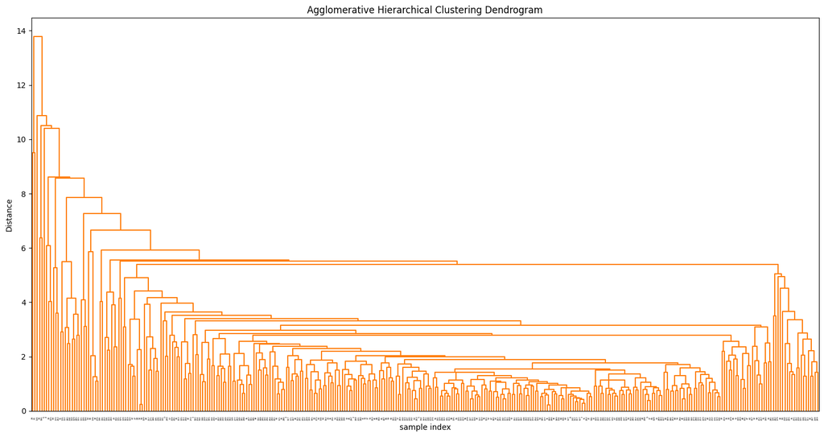

```python
# Plotting the Dendrogram
plt.figure(figsize=(15, 8))
plt.title("Agglomerative Hierarchical Clustering Dendrogram")
plt.xlabel("sample index")
plt.ylabel("Distance")
dendrogram(Z, leaf_rotation=90.0, color_threshold=40, leaf_font_size=3.0)
plt.tight_layout()
```

### [2] Creating a Clustering Algotrithm using Ward linkage and 5 clusters

```python
start_time = time.time()

# Creating and fitting the hierarchal clustering model w/ no. of clusters = 5 and Ward linkage measurement
model2 = AgglomerativeClustering(n_clusters=5, affinity="euclidean", linkage="ward")
model2.fit(dfScaled)

# Checking Output time
t3 = time.time() - start_time
print("--- %s seconds ---" % (time.time() - start_time))
```

```
--- 0.0039865970611572266 seconds ---
```

```python
# Copying the dataset
dfAttr2 = dfAttr

# Replacing the label column with the updated labels using model2
dfAttr2["labels"] = model2.labels_
o3 = dfAttr2["labels"].value_counts()
o3
```

```
1    286
3     25
0     13
2      9
4      5
Name: labels, dtype: int64
```

```python
# Checking the average statistics of each cluster
dfAttr2.groupby(["labels"]).mean()
```

| labels | Current Price | Price Change | Volatility | ROE | Cash Ratio | Earnings Per Share | P/E Ratio | P/B Ratio | Net Cash Flow (x10^7) | Net Income (x10^7) | Estimated Shares Outstanding (x10^7) |
| --- | --- | --- | --- | --- | --- | --- | --- | --- | --- | --- | --- |
| 0 | 192.617178 | 9.377017 | 1.488507 | 19.769231 | 345.923077 | 5.584615 | 32.828683 | 22.341093 | 318.539254 | 316.946177 | 103.752689 |
| 1 | 74.495818 | 5.509032 | 1.411497 | 35.118881 | 57.839161 | 3.657570 | 24.122558 | -2.985668 | 0.438734 | 152.105492 | 43.478056 |
| 2 | 46.672222 | 5.166566 | 1.079367 | 25.000000 | 58.333333 | 3.435556 | 15.596051 | -6.354193 | -304.066667 | 1484.844444 | 456.495995 |
| 3 | 44.382801 | -13.318960 | 2.745671 | 30.600000 | 65.560000 | -3.624400 | 106.713014 | 0.865374 | 21.251100 | -185.917428 | 60.223765 |
| 4 | 40.582000 | -11.976426 | 2.941678 | 427.800000 | 72.600000 | -33.256000 | 80.153016 | 2.392686 | -27.809600 | -1168.758960 | 33.948054 |

```python
# Checking the copenhet index
Z = linkage(dfScaled, metric="euclidean", method="ward")
c, coph_dists = cophenet(Z, pdist(dfScaled))

c
```

```
0.7003112389585903
```

- Changing the linkage to Ward leads to better distributed cluster but a significantly lower copenhet index

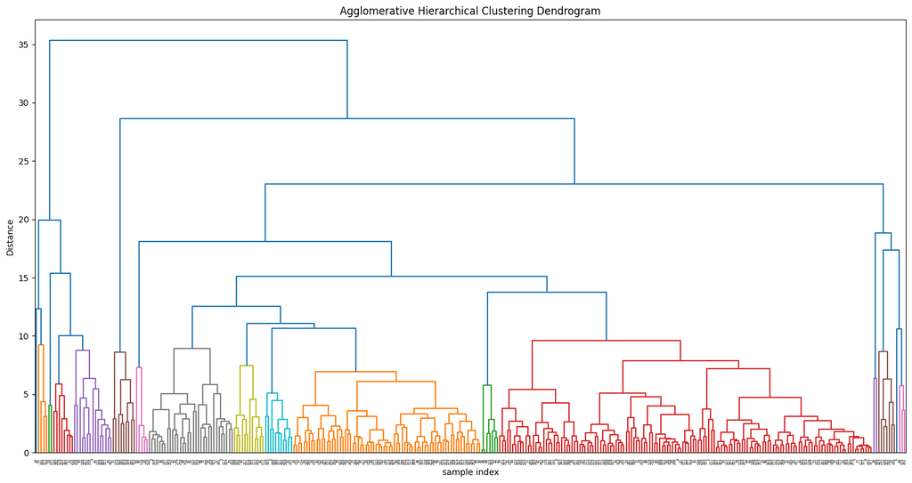

```python
# Plotting the Dendogram
plt.figure(figsize=(15, 8))
plt.title("Agglomerative Hierarchical Clustering Dendrogram")
plt.xlabel("sample index")
plt.ylabel("Distance")
dendrogram(Z, leaf_rotation=90.0, color_threshold=10, leaf_font_size=4.0)
plt.tight_layout()
```

- While the copenhet index is much lower, using Ward linkage for hierarchal clustering leads to a better distribution of datapoint density within each cluster
- Therefore we will use Ward linkage w/ 5 clusters as our hierarchal clustering algorithm

### Section Summary:

#### We created 2 Hierarchal clustering algorithms:

1] **3 Cluster, Eucledian Distance and Average Linkage:**

- Lead to a high copenhet value
- 99% of data was linked to one primary cluster
- other clusters seemed redundant

2] **5 Cluster, Eucledian Distance and Ward Linkage:**

- Significantly lower but still satisfactory copenhet value
- While there is still a primary dominant cluster, the number of datapoints in other clusters are significant enough to warrant the clustering algortihm
- We went for Model 2 as our primary hierarchal clustering algorithm

## K-means vs Hierarchical Clustering

You compare several things, like:

- Which clustering technique took less time for execution?
- Which clustering technique gave you more distinct clusters, or are they the same?
- How many observations are there in the similar clusters of both algorithms?
- How many clusters are obtained as the appropriate number of clusters from both algorithms?

You can also mention any differences or similarities you obtained in the cluster profiles from both the clustering techniques.

```python
# Creating a Dataframe to compare the computation time of the clustering algorithms
comparison_frame = pd.DataFrame(
    {
        "Model": [
            "KMeans",
            "Hierarchal using Average Linkage",
            "Hierarchal using Ward Linkage",
        ],
        "Execution Time (s)": [t1, t2, t3],
    }
)
comparison_frame
```

|  | Model | Execution Time (s) |
| --- | --- | --- |
| 0 | KMeans | 0.029018 |
| 1 | Hierarchal using Average Linkage | 0.003987 |
| 2 | Hierarchal using Ward Linkage | 0.003987 |

- We can see that both Hierarchal clustering algorithms took significantly less time to execute than KMeans, while all the execution times are insignificant in this case due to the small dataset we are working with, it can be advantageous to work with hierarchal clustering for larger data
- While both; the Hierarchal clustering using ward linkage and KMeans provided strongly distinct clusters, the KMeans clusters were easier to analyse and had more features to act as clear indicators to which cluster the data belonged to

```python
# Creating a Dataframe to compare the number of observations for each clustering algorithm
comparison_frame2 = pd.DataFrame(
    {
        "KMeans": o1,
        "Hierarchal using Average Linkage": o2,
        "Hierarchal using Ward Linkage": o3,
    }
)
comparison_frame2
```

|  | KMeans | Hierarchal using Average Linkage | Hierarchal using Ward Linkage |
| --- | --- | --- | --- |
| 0 | 282.0 | 335.0 | 13 |
| 1 | 18.0 | 2.0 | 286 |
| 2 | 29.0 | 1.0 | 9 |
| 3 | 9.0 | NaN | 25 |
| 4 | NaN | NaN | 5 |

- Hierarchal clustering using average linkage lead to over 99% of the datapoints being grouped into one cluster
- Hierarchal using Ward linkage and KMeans clustering both shared a similar distribution in number of observations with the number of clusters for each algortihm being slightly different (4 for KMeans and 5 for Hierarchal using Ward)

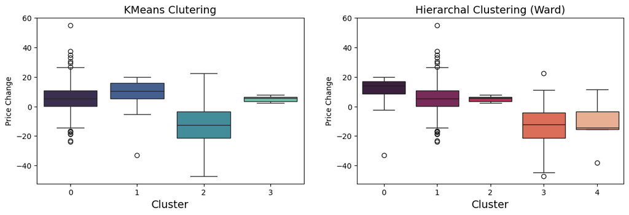

```python
# Grouping data according to the clusters and looking at how Price Change vary for each one
f, axes = plt.subplots(1, 2, figsize=(14, 4))


# KMeans Plot
sns.boxplot(
    x="GROUP",
    y="Price Change",
    data=df,
    ax=axes[0],
    palette="mako",
)
axes[0].set_xlabel("Cluster", fontsize=14)
axes[0].set_title("KMeans Clutering", fontsize=14)


# Hierarchal Clust. Plot
sns.boxplot(
    x="labels",
    y="Price Change",
    data=dfAttr2,
    ax=axes[1],
    palette="rocket",
)
axes[1].set_xlabel("Cluster", fontsize=14)
axes[1].set_title("Hierarchal Clustering (Ward)", fontsize=14)


plt.show()
```

- We can see that the price changes are largely varied for both datasets so both clustering algorithms are a good choice to utilize for stock analysis
- I'm leaned more towards KMeans as it was easier to analyze and each cluster hosts datapoints with distinct features

## Actionable Insights and Recommendations

- From our EDA we can see that the Energy Sector largely suffered heavy losses with an average of 10% decrease in stock value in the past 13 weeks
- Opposingly, Healthcare and Consumer Staples are seeing strong increases in stock value
- We've seen that more volatile companies are more likely to suffer stock price losses and have higher P/E ratios than more stable companies

#### After scaling the features, I've designed 3 clustering algorithms - KMeans, Hierarchal using Average Linkage and Hierarchal using Ward Linkage:

- Hierarchal using Average Linkage did not cluster the data in a manner where analysing each cluster would prove to be useful as almost all the data belonged in one cluster
- KMeans gave us 4 clusters all with distinct features, however the computation time was about 8 times longer than Hierarchal Clustering
- Ward linkage clustering gave us 5 clusters, while the computation time was fast and each cluster had a sound distribution of datapoints, the KMeans clusters were personally easier to analyse and make stock decisions with

#### For KMeans clustering, this was our inference for each cluster (Taken from KMeans Section Summary):

- Cluster 2 is the most volatile cluster with high P/E Ratios, losses in share prices and net income
- Cluster 0 consists of the majority data and lies around the median of each metric of the box plot with some strong outliers
- Cluster 1 is characterized by it's high P/B and Cash Ratios as well as high current share prices
- Cluster 3 has the highest net income of all clusters by a wide margin with high outstanding estimated shares and a largely negative net cash flow